=== Week3-4_class.Rmd Requires: fpp, forecast packages ===

Most of this code is adapted from the code available with the FPP book First let’s look at how to implement simple exponential smoothing (SES)

```r
require(fpp)
```

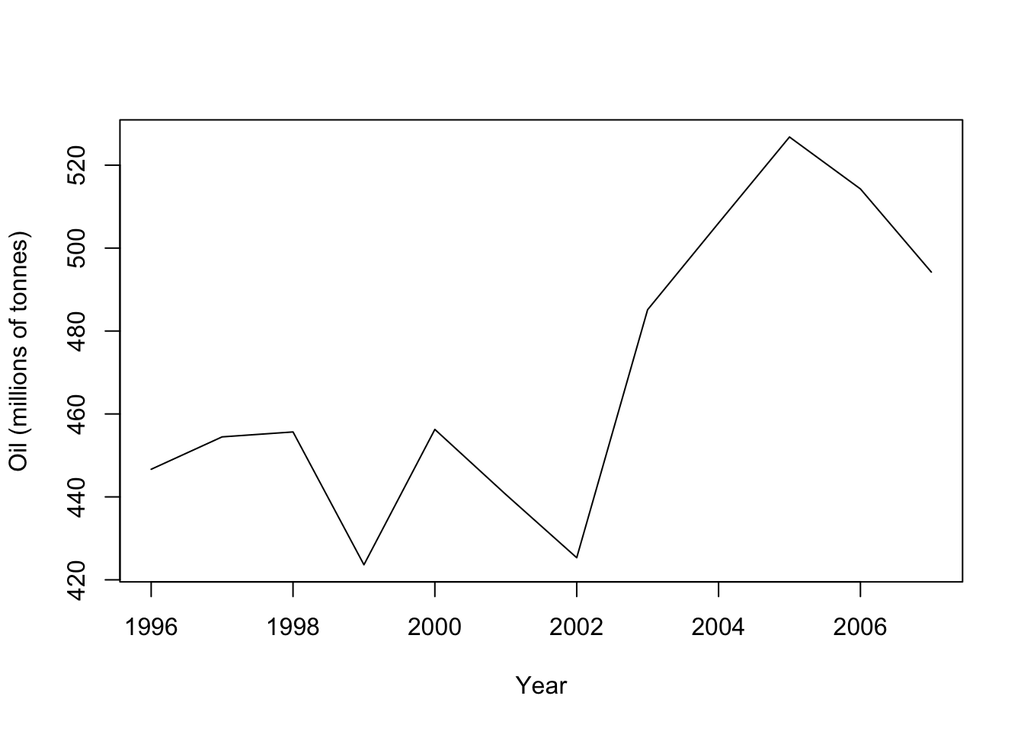

```r
# Simple exponential smoothing - code from the FPP book

oildata <- window(oil, start = 1996, end = 2007)
plot(oildata, ylab = "Oil (millions of tonnes)", xlab = "Year")
```

```r
fit1 <- ses(oildata, alpha = 0.2, initial = "simple", h = 3)
fit2 <- ses(oildata, alpha = 0.6, initial = "simple", h = 3)
fit3 <- ses(oildata, h = 3) #note no value for alpha and no initial value.  The algorithm will calculate alpha as part of the optimization.

#what kind of objects are these?
class(fit3)
```

```
## [1] "forecast"
```

```r
#what is in them
summary(fit3)
```

```
##
## Forecast method: Simple exponential smoothing
##
## Model Information:
## Simple exponential smoothing
##
## Call:
##  ses(y = oildata, h = 3)
##
##   Smoothing parameters:
##     alpha = 0.8921
##
##   Initial states:
##     l = 447.4808
##
##   sigma:  25.1221
##
##      AIC     AICc      BIC
## 113.1888 116.1888 114.6435
##
## Error measures:
##                    ME     RMSE      MAE       MPE     MAPE      MASE
## Training set 4.578526 25.12207 20.05797 0.8091703 4.252042 0.9245025
##                     ACF1
## Training set -0.03891839
##
## Forecasts:
##      Point Forecast    Lo 80    Hi 80    Lo 95    Hi 95
## 2008       496.4923 464.2971 528.6876 447.2540 545.7307
## 2009       496.4923 453.3488 539.6359 430.5100 562.4747
## 2010       496.4923 444.6638 548.3208 417.2275 575.7572
```

Notice: we used the SES command and it executed the ETS(A,N,N) command. ses is just a wrapper for ETS.

Also notice the estimate for alpha. That came from the optimization. So did the initial state number (447.48)

Let’s look at some pictures.

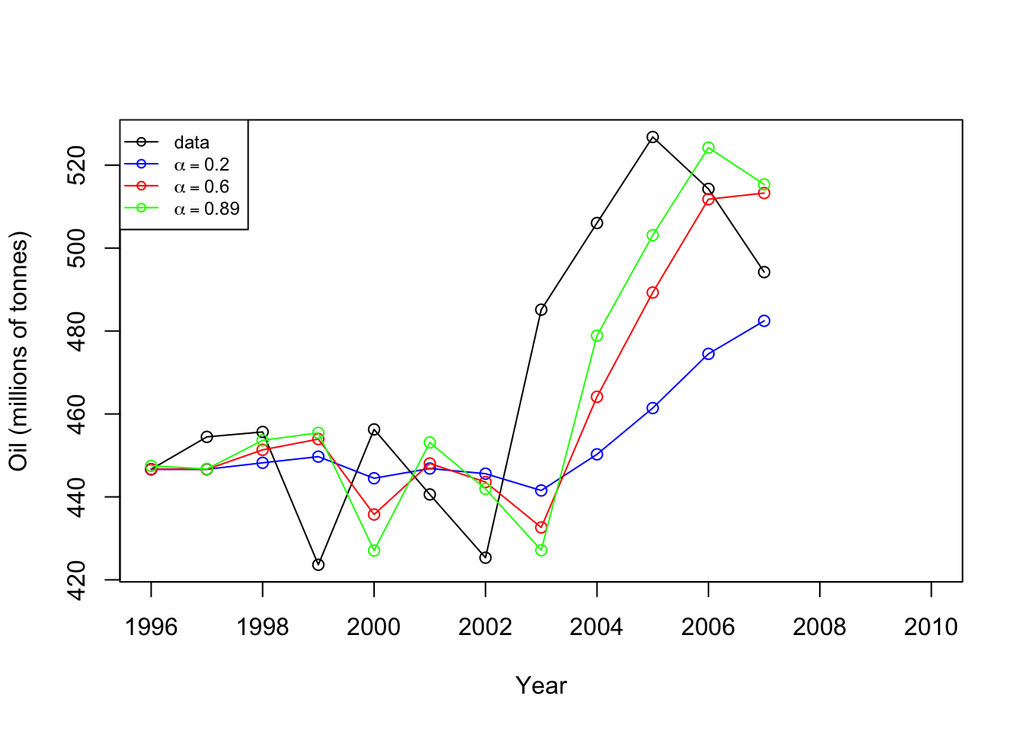

```r
plot(fit1, PI=FALSE, ylab="Oil (millions of tonnes)",
     xlab="Year", main="", fcol="white", type="o")
lines(fitted(fit1), col="blue", type="o")
lines(fitted(fit2), col="red", type="o")
lines(fitted(fit3), col="green", type="o")

legend("topleft",lty=1, col=c(1,"blue","red","green"), cex = 0.75,
       c("data", expression(alpha == 0.2), expression(alpha == 0.6),
         expression(alpha == 0.89)),pch=1)
```

This just covers our existing data - we’ve fitted the data with several options for the smoothing parameter. Notice how flat things get when alpha is really small.

Now let’s try forecasting - we’re fitting these smoothing methods to data through 2007 but our data really goes through 2010

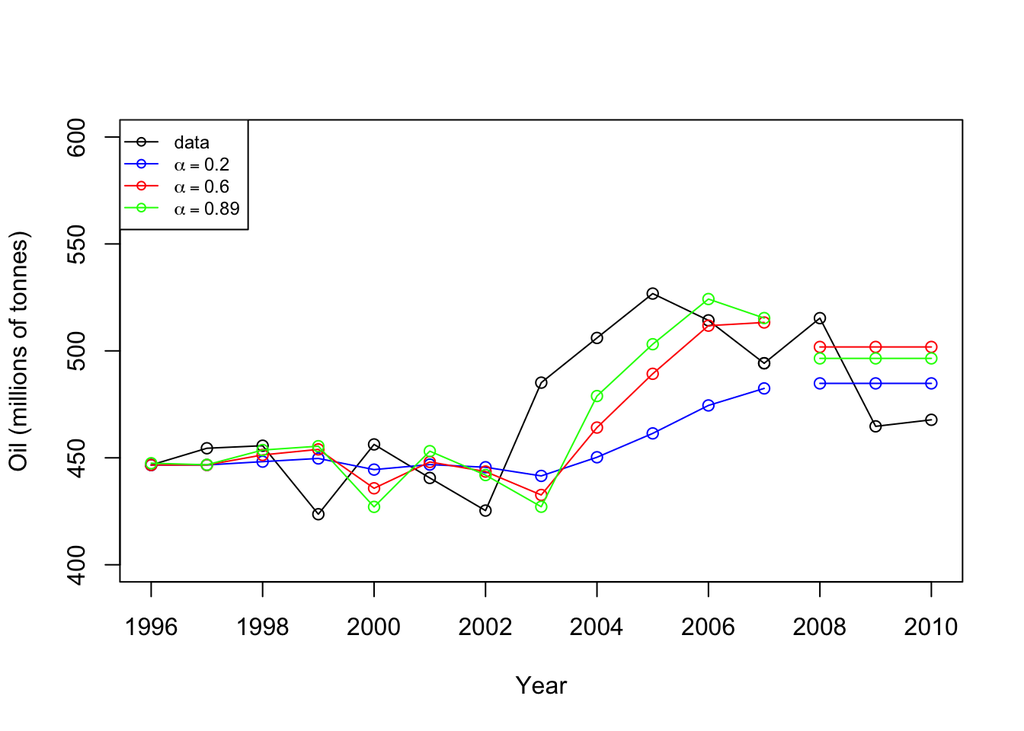

```r
fit1 <- ses(oildata, alpha = 0.2, initial = "simple", h = 3)
fit2 <- ses(oildata, alpha = 0.6, initial = "simple", h = 3)
fit3 <- ses(oildata, h = 3)

plot(fit1, PI=FALSE, ylim = c(400, 600), ylab="Oil (millions of tonnes)",
xlab="Year", main="", fcol="white", type="o")
#this just plots the data through 2007 because that's what we ran the model over
#we have more data but have to plot it seperately if we want to compare the forecast with the actual
# add these lines for putting the actual data past 2007
test.oil <- window(oil, start = 2007)
lines(test.oil, col = "black", type = "o")
lines(fitted(fit1), col="blue", type="o")
lines(fitted(fit2), col="red", type="o")
lines(fitted(fit3), col="green", type="o")
lines(fit1$mean, col="blue", type="o")
lines(fit2$mean, col="red", type="o")
lines(fit3$mean, col="green", type="o")
legend("topleft",lty=1, cex =0.75, col=c(1,"blue","red","green"),
c("data", expression(alpha == 0.2), expression(alpha == 0.6),
expression(alpha == 0.89)),pch=1)
```

Next set of methods: Holt exponential smoothing.

```r
fith <- holt(oildata, alpha=0.8, beta=0.2, initial="simple", h=3)
class(fith)
```

```
## [1] "forecast"
```

```r
summary(fith)
```

```
##
## Forecast method: Holt's method
##
## Model Information:
## Holt's method
##
## Call:
##  holt(y = oildata, h = 3, initial = "simple", alpha = 0.8, beta = 0.2)
##
##   Smoothing parameters:
##     alpha = 0.8
##     beta  = 0.2
##
##   Initial states:
##     l = 446.6565
##     b = 7.8168
##
##   sigma:  26.9797
## Error measures:
##                     ME     RMSE      MAE       MPE     MAPE     MASE
## Training set -1.768733 26.97966 22.20042 -0.526348 4.718622 1.023252
##                    ACF1
## Training set 0.03909422
##
## Forecasts:
##      Point Forecast    Lo 80    Hi 80    Lo 95    Hi 95
## 2008       505.5729 470.9971 540.1487 452.6938 558.4521
## 2009       509.9937 461.0961 558.8913 435.2113 584.7762
## 2010       514.4146 450.2859 578.5432 416.3383 612.4908
```

```r
oildata[1]
```

```
## [1] 446.6565
```

Notice that it shows the parameter settings we gave it. We now have a setting for the effect of the trend. What’s the initial value? It’s the first value of the oildata series - because we set the initialization routine = “simple”

Adding these lines to our chart. What is the effect of adding trend?

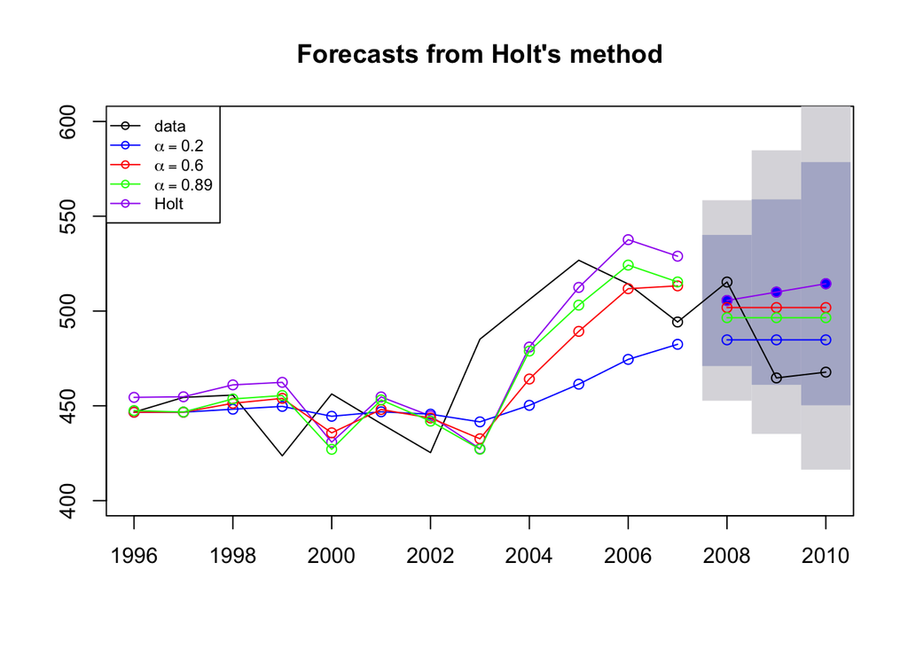

```r
plot(fith, PI=TRUE, ylim = c(400, 600))
lines(fitted(fith), type = "o", col="purple")
lines(fith$mean, col="purple", type="o")
lines(test.oil, col = "black", type = "o")
lines(fitted(fit1), col="blue", type="o")
lines(fitted(fit2), col="red", type="o")
lines(fitted(fit3), col="green", type="o")
lines(fit1$mean, col="blue", type="o")
lines(fit2$mean, col="red", type="o")
lines(fit3$mean, col="green", type="o")
legend("topleft",lty=1, cex = 0.75, col=c(1,"blue","red","green", "purple"),
       c("data", expression(alpha == 0.2), expression(alpha == 0.6),
         expression(alpha == 0.89),"Holt"),pch=1)
```

That was the additive trend model - let’s make it muliplicative.

```r
fith2 <- holt(oildata,alpha=0.8,beta=0.2,initial="simple",exponential=TRUE,h=3)
summary(fith2)
```

[output not shown]

We specified alpha and beta and told it to start with the initial value and the initial trend.

Now add that line to the chart:

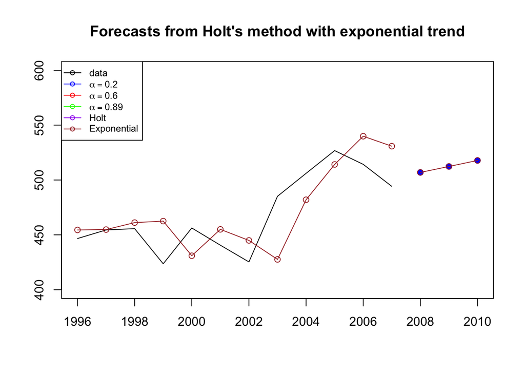

```r
plot(fith2, PI=FALSE, ylim = c(400, 600))
lines(fitted(fith2), col="brown", type = "o")
lines(fith2$mean, col="brown", type="o")
legend("topleft", cex =0.75, lty=1, col=c(1,"blue","red","green", "purple", "brown"),
       c("data", expression(alpha == 0.2), expression(alpha == 0.6),
         expression(alpha == 0.89),"Holt","Exponential"),pch=1)
```

Let’s compare the simple exponential smoothing with the Holt model

```r
air <- window(ausair,start=1990,end=2004)
fit0 <- ses(air, alpha = 0.8, beta = 0.2,initial = "simple", h=5)
fit1 <- holt(air, alpha=0.8, beta=0.2, initial="simple", h=5)
fit2 <- holt(air,alpha=0.8,beta=0.2,initial="simple",exponential=TRUE,h=5)

fit3 <- holt(air, alpha=0.8, beta=0.2, damped=TRUE, h=5)
fit4 <- holt(air, alpha=0.8, beta=0.2, damped=TRUE, exponential = TRUE, h=5)


# Results for first model:
fit1$model$state
```

```
## Time Series:
## Start = 1989
## End = 2004
## Frequency = 1
##             l        b
## 1989 17.55340 4.306700
## 1990 18.41474 3.617628
## 1991 21.89455 3.590065
## 1992 24.20620 3.334382
## 1993 27.05156 3.236576
## 1994 27.56843 2.692635
## 1995 29.11733 2.463889
## 1996 30.37632 2.222910
## 1997 31.28265 1.959592
## 1998 30.79701 1.470546
## 1999 31.71727 1.360489
## 2000 32.67761 1.280459
## 2001 33.57353 1.203552
## 2002 38.17268 1.882672
## 2003 41.12022 2.095644
## 2004 41.92041 1.836555
```

```r
fitted(fit1)
```

```
## Time Series:
## Start = 1990
## End = 2004
## Frequency = 1
##  [1] 21.86010 22.03237 25.48462 27.54059 30.28813 30.26106 31.58122
##  [8] 32.59923 33.24224 32.26755 33.07776 33.95807 34.77708 40.05535
## [15] 43.21586
```

```r
fit1$mean
```

```
## Time Series:
## Start = 2005
## End = 2009
## Frequency = 1
## [1] 43.75697 45.59352 47.43008 49.26663 51.10319
```

The forecast object has the fitted and the forecast values as well as the values for the trend and the level.

You can plot those pieces:

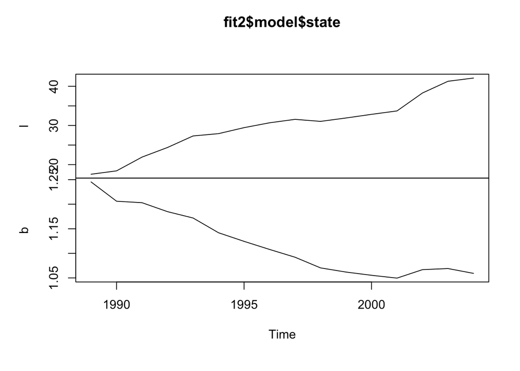

```r
plot(fit2$model$state)
```

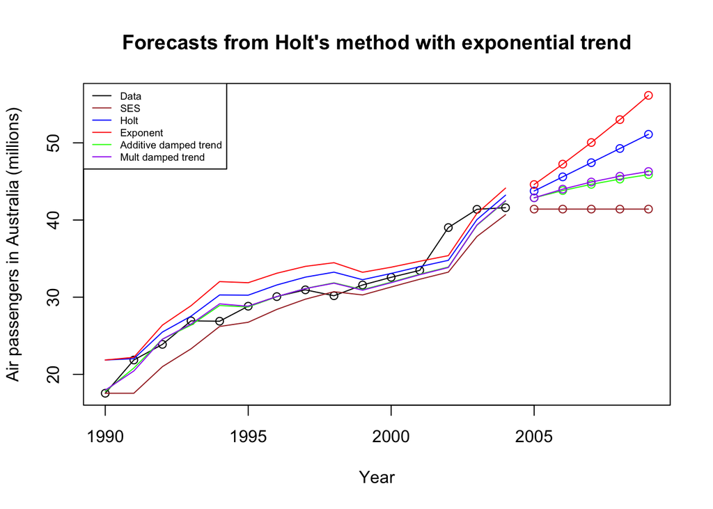

```r
plot(fit2, type="o", ylab="Air passengers in Australia (millions)",
     xlab="Year", fcol="white", PI=FALSE)
lines(fitted(fit0), col="brown")
lines(fitted(fit1), col="blue")
lines(fitted(fit2), col="red")
lines(fitted(fit3), col="green")
lines(fitted(fit4), col="purple")
lines(fit0$mean, col="brown", type="o")
lines(fit1$mean, col="blue", type="o")
lines(fit2$mean, col="red", type="o")
lines(fit3$mean, col="green", type="o")
lines(fit4$mean, col="purple", type="o")

legend("topleft", lty=1, cex=0.6, col=c("black","brown","blue","red","green", "purple"),
       c("Data","SES", "Holt","Exponent","Additive damped trend", "Mult damped trend"))
```

So we can see how the forecast differs across various methods. What is the effect of changing the parameters for any single method?

[figure not shown]

```r
livestock2 <- window(livestock,start=1970,end=2000)
fit1 <- holt(livestock2,alpha = 0.8, beta = .1)
fit2 <- holt(livestock2, alpha = .6, beta = .1)
fit3 <- holt(livestock2,alpha = .4, beta = .1)



plot(fit3, type="o", ylab="Livestock, sheep in Asia (millions)", ylim = c(250, 475),
     flwd=1, PI=FALSE, xlab = "beta = 0.1")
lines(window(livestock,start=2001),type="o")
lines(fit1$mean,col=2)
lines(fit2$mean,col=3)

legend("topleft", cex = 0.75, lty=1, pch=1, col=1:4,
       c("Data","Alpha = 0.8","Alpha = 0.4","Alpha = 0.2"))
```

Trend parameter:

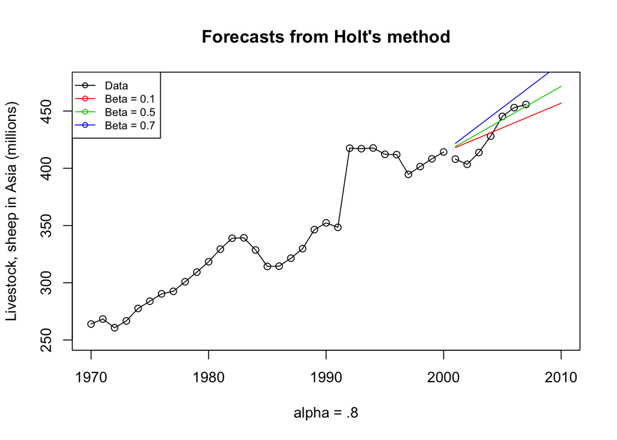

```r
livestock2 <- window(livestock,start=1970,end=2000)
fit1 <- holt(livestock2,alpha = 0.8, beta = .1)
fit2 <- holt(livestock2, alpha = .8, beta = .5)
fit3 <- holt(livestock2,alpha = .8, beta = .7)



plot(fit3, type="o", ylab="Livestock, sheep in Asia (millions)", ylim = c(250, 475),
     flwd=1, PI=FALSE, xlab = "alpha = .8")
lines(window(livestock,start=2001),type="o")
lines(fit1$mean,col=2)
lines(fit2$mean,col=3)

legend("topleft", cex = 0.75, lty=1, pch=1, col=1:4,
       c("Data","Beta = 0.1","Beta = 0.5","Beta = 0.7"))
```

HW Seasonal models Let’s look at Tourists to Australia

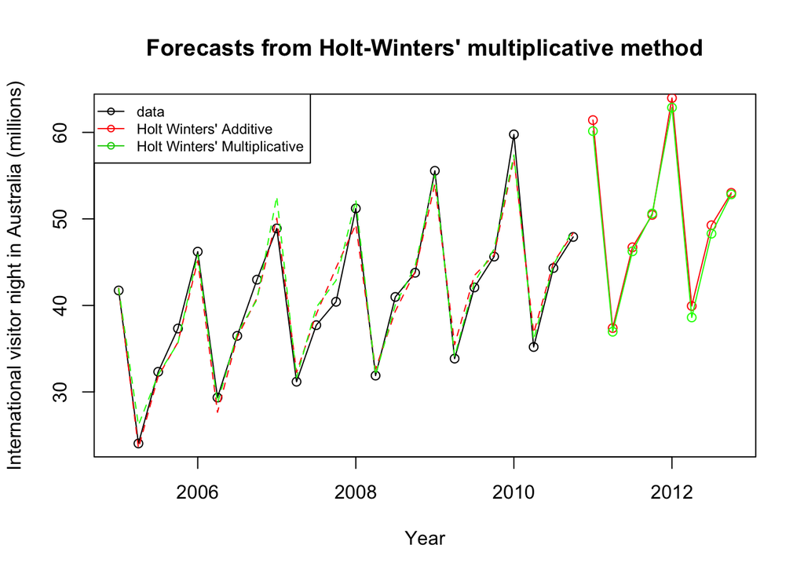

```r
aust <- window(austourists,start=2005)
fit1hw <- hw(aust,seasonal="additive")
fit2hw <- hw(aust,seasonal="multiplicative")
fit3hw <- hw(aust,seasonal="additive", damped = TRUE)

plot(fit2hw,ylab="International visitor night in Australia (millions)",
     PI=FALSE, type="o", fcol="white", xlab="Year")
lines(fitted(fit1hw), col="red", lty=2)
lines(fitted(fit2hw), col="green", lty=2)
lines(fit1hw$mean, type="o", col="red")
lines(fit2hw$mean, type="o", col="green")
legend("topleft",lty=1, cex = 0.75, pch=1, col=1:3,
  c("data","Holt Winters' Additive","Holt Winters' Multiplicative"))
```

We can pull the different pieces out of the forecast object and compare them across specifications. What’s the difference between additive seasonal and multiplicative seasonal?

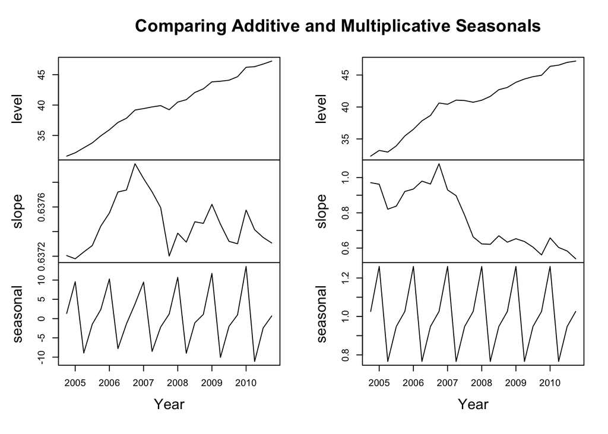

```r
states <- cbind(fit1hw$model$states[,1:3],fit2hw$model$states[,1:3])
colnames(states) <- c("level","slope","seasonal","level","slope","seasonal")
plot(states, xlab="Year", main = "Comparing Additive and Multiplicative Seasonals")
```

Let’s revisit the oil data - we originally used the SES model on it which is equivalent to ETS(A,N,N)

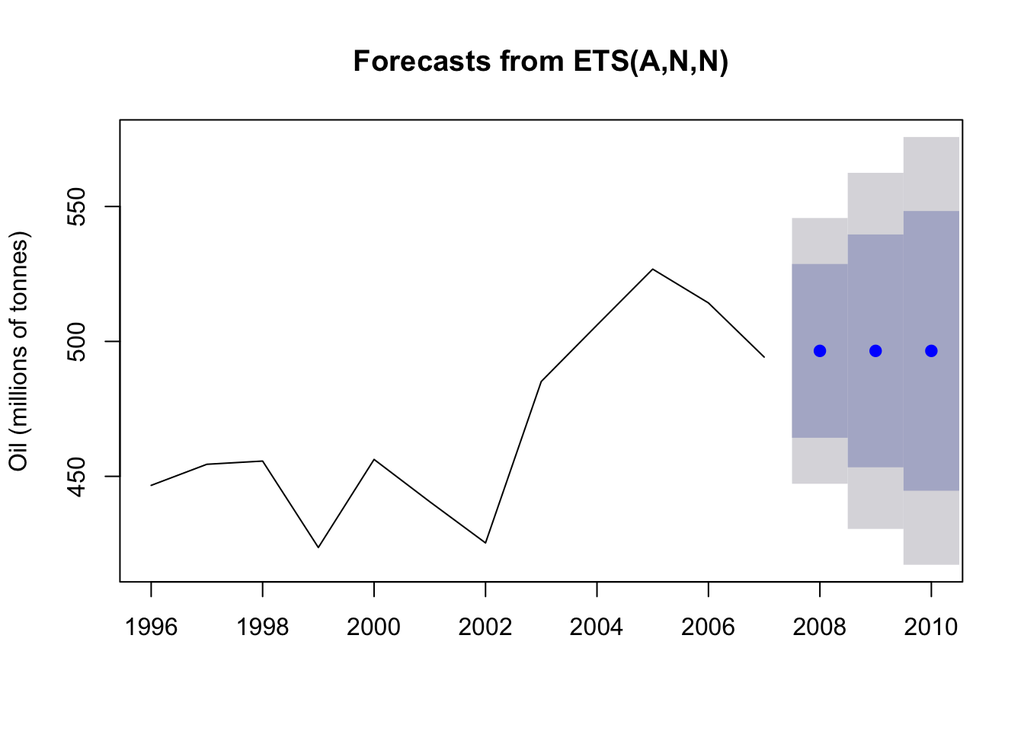

```r
oildata <- window(oil, start = 1996, end = 2007)
fita <- ets(oildata, model = "ANN")
plot(forecast(fita, h=3), ylab="Oil (millions of tonnes)")
```

```r
summary(fita)
```

```
## ETS(A,N,N)
##
## Call:
##  ets(y = oildata, model = "ANN")
##
##   Smoothing parameters:
##     alpha = 0.8919
##
##   Initial states:
##     l = 447.4882
##
##   sigma:  25.1221
##
##      AIC     AICc      BIC
## 113.1888 116.1888 114.6435
##
## Training set error measures:
##                    ME     RMSE      MAE       MPE     MAPE      MASE
## Training set 4.578637 25.12207 20.05858 0.8091693 4.252165 0.9245306
##                     ACF1
## Training set -0.03883812
```

```r
ls(fita)  #list names of the objects in the specified environment
```

```
##  [1] "aic"        "aicc"       "amse"       "bic"        "call"
##  [6] "components" "fit"        "fitted"     "initstate"  "loglik"
## [11] "m"          "method"     "mse"        "par"        "residuals"
## [16] "series"     "sigma2"     "states"     "x"
```

```r
fita$par
```

```
##       alpha           l
##   0.8919431 447.4881561
```

What if we used the ETS(M,N,N) model?

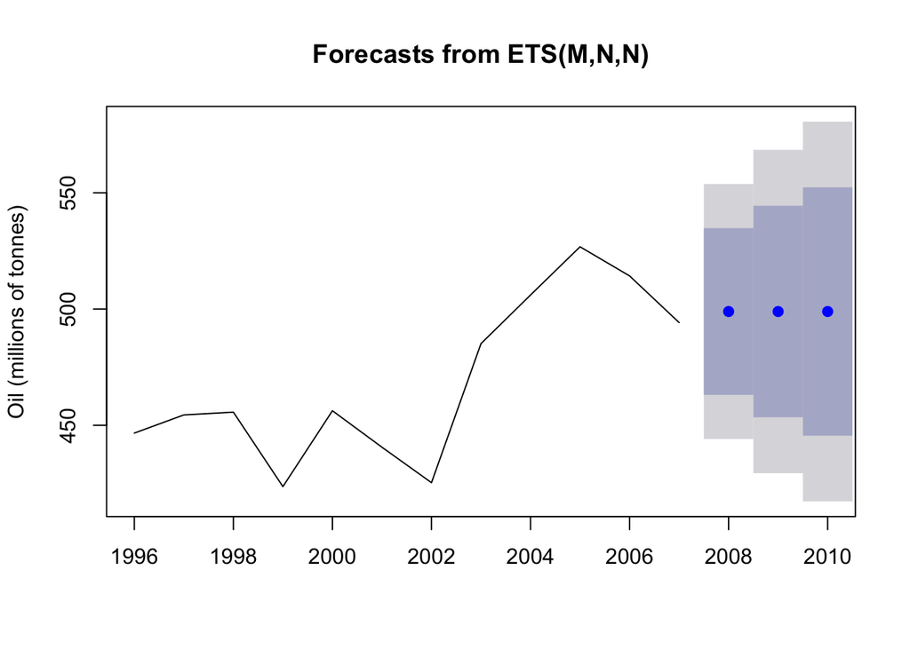

```r
oildata <- window(oil, start = 1996, end = 2007)
fitm <- ets(oildata, model = "MNN")
plot(forecast(fitm, h=3), ylab="Oil (millions of tonnes)")
```

```r
summary(fitm)
```

```
## ETS(M,N,N)
##
## Call:
##  ets(y = oildata, model = "MNN")
##
##   Smoothing parameters:
##     alpha = 0.7792
##
##   Initial states:
##     l = 446.5023
##
##   sigma:  0.0561
##
##      AIC     AICc      BIC
## 113.9507 116.9507 115.4054
##
## Training set error measures:
##                    ME    RMSE      MAE      MPE     MAPE     MASE
## Training set 5.609268 25.2454 20.04763 1.010039 4.236011 0.924026
##                    ACF1
## Training set 0.03995039
```

```r
ls(fitm)  #list names of the objects in the specified environment
```

```
##  [1] "aic"        "aicc"       "amse"       "bic"        "call"
##  [6] "components" "fit"        "fitted"     "initstate"  "loglik"
## [11] "m"          "method"     "mse"        "par"        "residuals"
## [16] "series"     "sigma2"     "states"     "x"
```

```r
fitm$par
```

```
##       alpha           l
##   0.7791632 446.5023351
```

But are either of these the right model for these data? What if we let the ETS code decide?

```r
oildata <- window(oil, start = 1996, end = 2007)
fit <- ets(oildata)
summary(fit)
```

```
## ETS(A,N,N)
##
## Call:
##  ets(y = oildata)
##
##   Smoothing parameters:
##     alpha = 0.8919
##
##   Initial states:
##     l = 447.4882
##
##   sigma:  25.1221
##
##      AIC     AICc      BIC
## 113.1888 116.1888 114.6435
##
## Training set error measures:
##                    ME     RMSE      MAE       MPE     MAPE      MASE
## Training set 4.578637 25.12207 20.05858 0.8091693 4.252165 0.9245306
##                     ACF1
## Training set -0.03883812
```

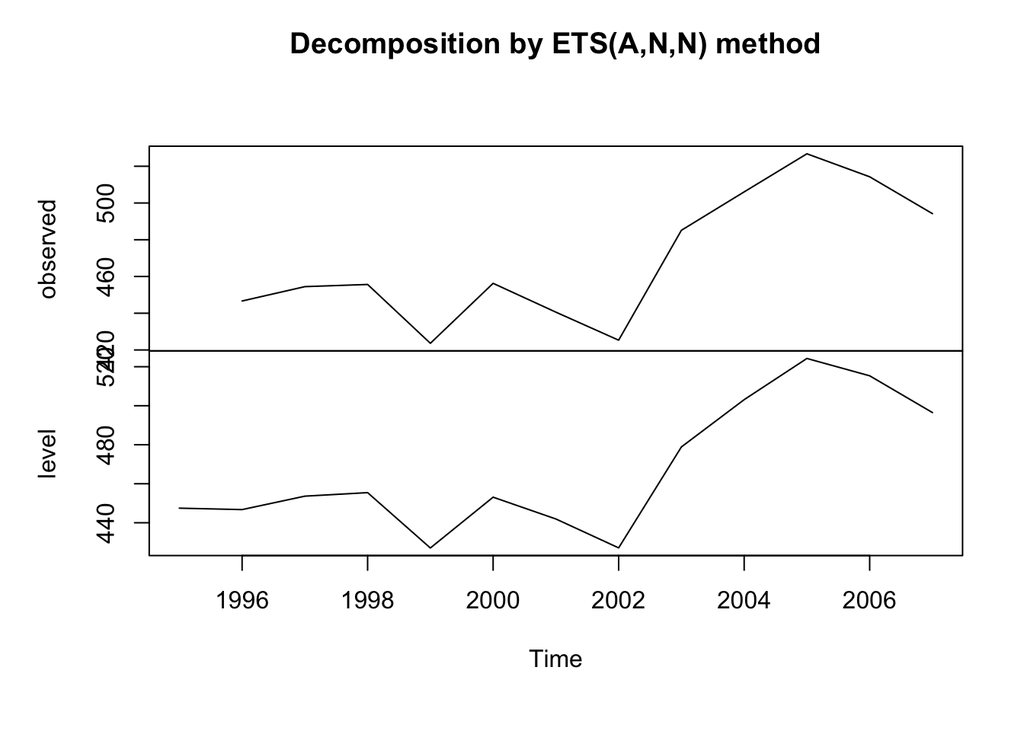

```r
plot(fit)
```

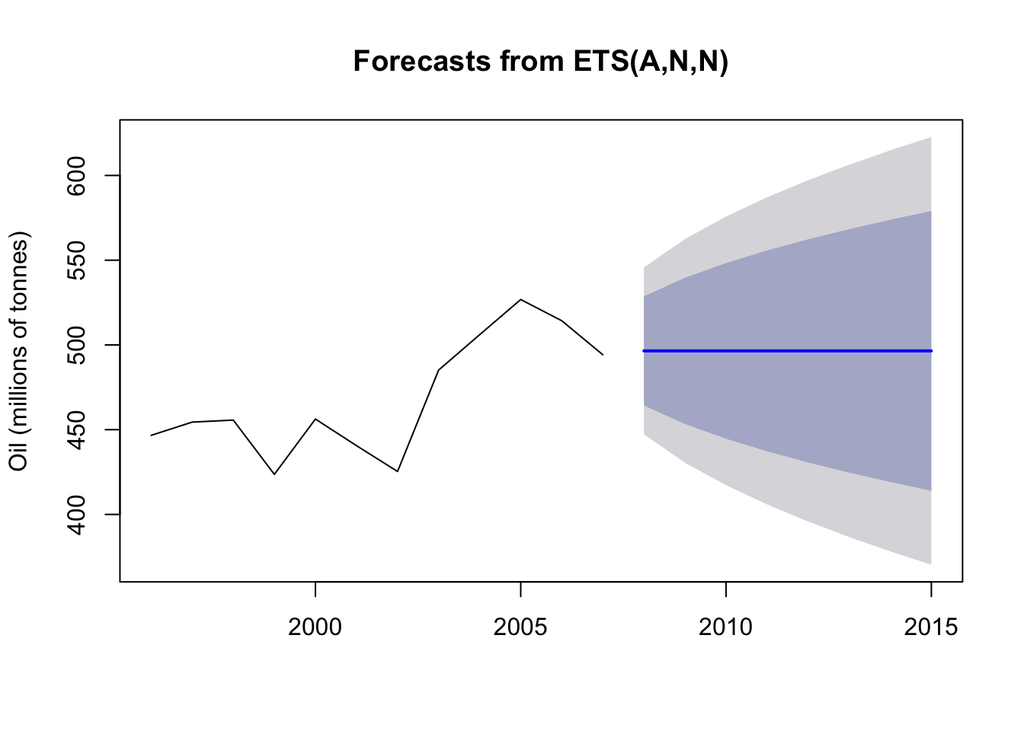

```r
plot(forecast(fit, h = 8), ylab = "Oil (millions of tonnes)")
```

The model chose additive. Compare the AIC for the two we examined.

```r
fita$aic
```

```
## [1] 113.1888
```

```r
fitm$aic
```

```
## [1] 113.9507
```

Yup - the AIC for the additive model is lower so it is the “better” model

How about a more interesting example? Remember the Australian visitors data?

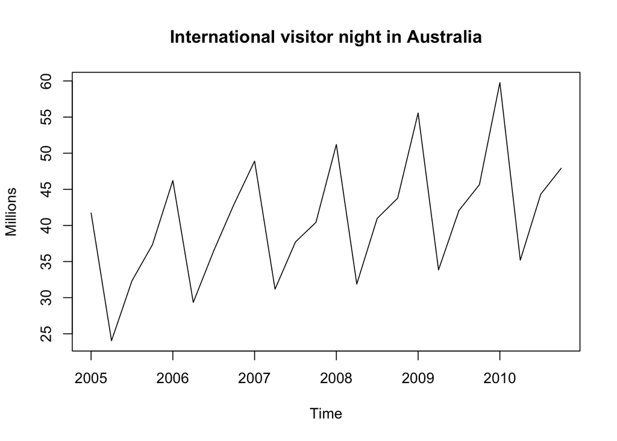

```r
aust <- window(austourists,start=2005)
plot(aust, main = "International visitor night in Australia", ylab = "Millions")
```

Very strongly seasonal. Probably not a good candidate for the ETS(A,N,N) model. Let’s see:

```r
fit <- ets(aust)
summary(fit)
```

```
## ETS(M,N,M)
##
## Call:
##  ets(y = aust)
##
##   Smoothing parameters:
##     alpha = 0.7673
##     gamma = 1e-04
##
##   Initial states:
##     l = 32.9088
##     s=1.0317 0.9438 0.7617 1.2628
##
##   sigma:  0.0412
##
##      AIC     AICc      BIC
## 113.4198 120.4198 121.6661
##
## Training set error measures:
##                     ME    RMSE      MAE      MPE     MAPE      MASE
## Training set 0.7381341 1.64236 1.313633 1.781574 3.251206 0.4618879
##                    ACF1
## Training set -0.3173166
```

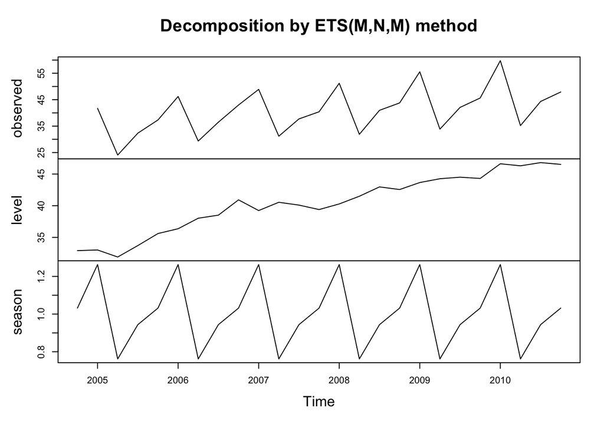

```r
plot(fit)
```

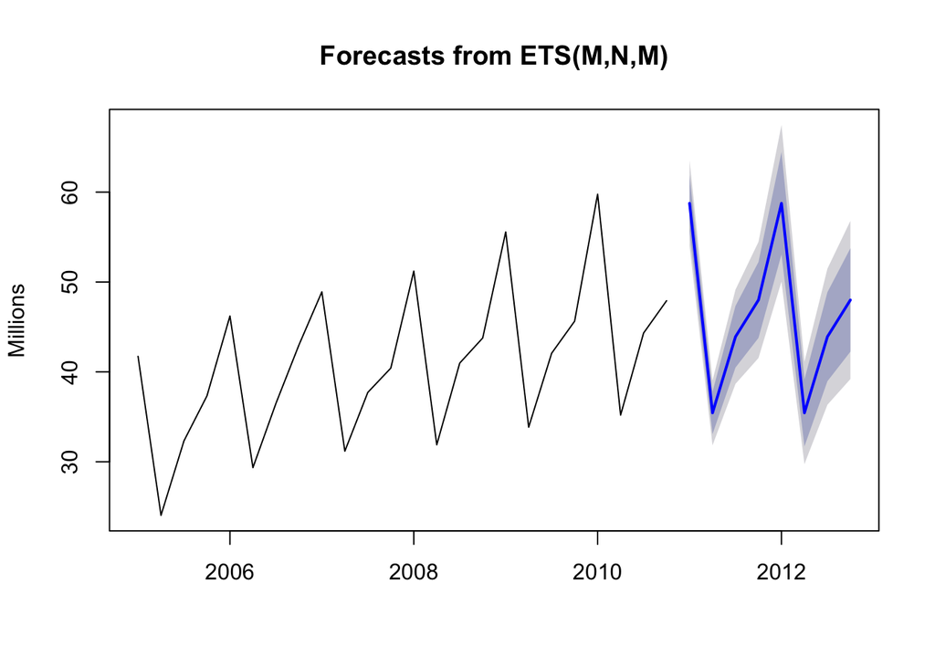

```r
plot(forecast(fit, h = 8), ylab = "Millions")
```

What about our ubiquitous air passengers data?

```r
ap <- window(AirPassengers, start = 1949, end = 1958)
fit <- ets(ap)
summary(fit)
```

```
## ETS(M,Ad,M)
##
## Call:
##  ets(y = ap)
##
##   Smoothing parameters:
##     alpha = 0.768
##     beta  = 0.0268
##     gamma = 1e-04
##     phi   = 0.98
##
##   Initial states:
##     l = 120.2681
##     b = 1.85
##     s=0.8985 0.796 0.9173 1.0571 1.1946 1.2146
##            1.1057 0.9791 0.9911 1.0345 0.9033 0.9083
##
##   sigma:  0.0338
##
##       AIC      AICc       BIC
##  980.8984  988.4984 1029.3427
##
## Training set error measures:
##                    ME     RMSE      MAE      MPE     MAPE      MASE
## Training set 1.117493 7.459698 5.985233 0.372253 2.717772 0.1961377
##                    ACF1
## Training set 0.04383336
```

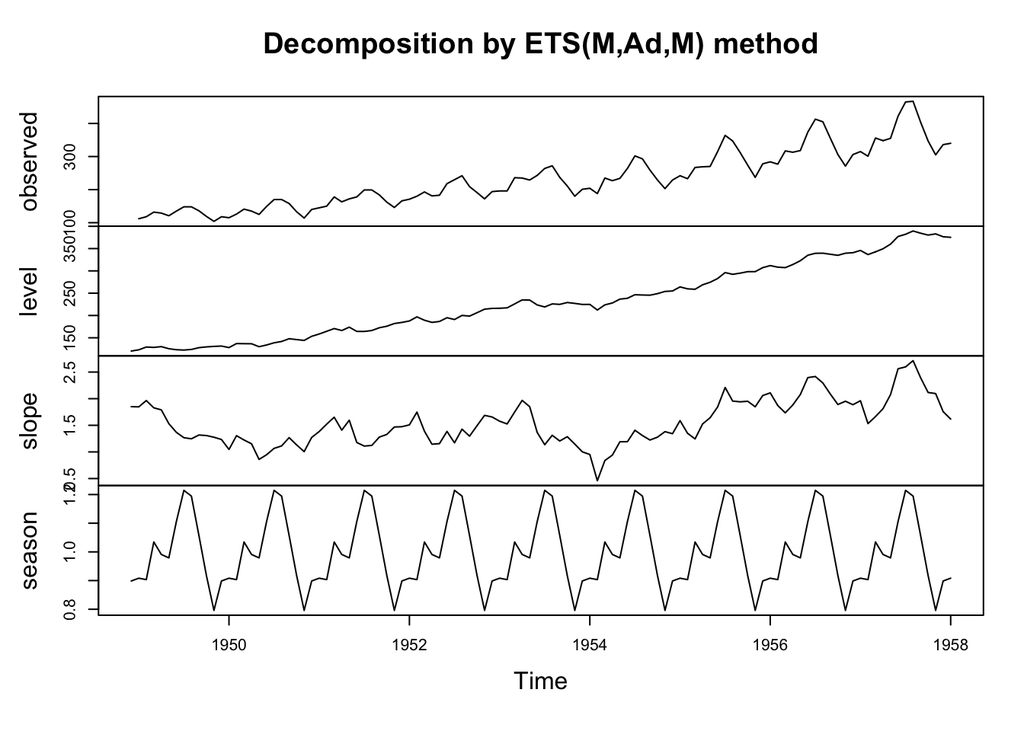

```r
plot(fit)
```

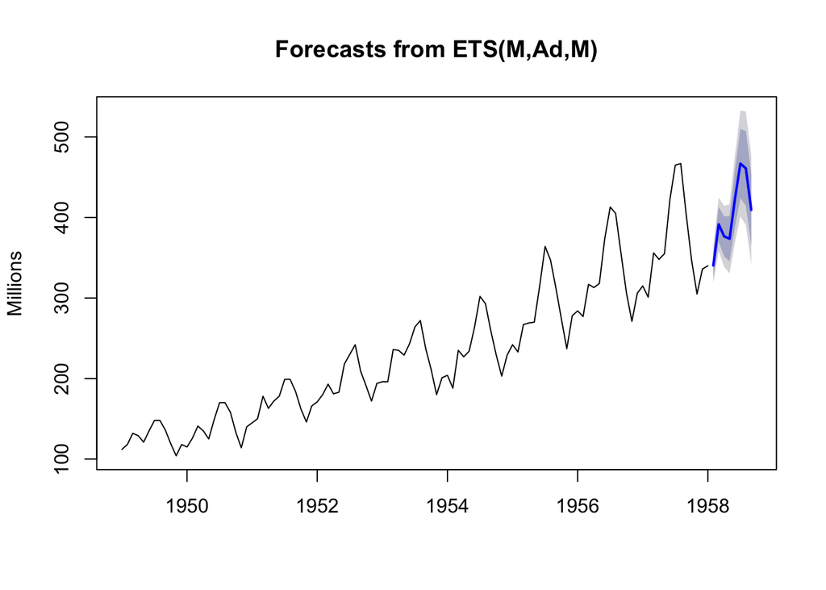

```r
plot(forecast(fit, h = 8), ylab = "Millions")
```

Same thing.